# Assignment 4

#### Question 2b (4pts)

*EdgeR is exceptionally versatile, with many different options for analysis. Today, you’re going to use the GLM-quasi-likelihood approach to calculate differential expression. Below is some incomplete code that you can use to start with. Please complete the code so that edgeR uses your countMatrix to calculate differential expression comparing B cells to LCLs. Please also comment the code so that it is clear what each step does (in your own words).*

```r
###get the group information
ct=as.factor(gsub("([A-Z]+)_[ABCDE]","\\1",colnames(countMatrix)))
###produce DGElist
res= DGEList(counts=countMatrix, group=ct)
###since different samples have different coverage, so we need calculate the normalization factor
res = calcNormFactors(res)
###then get the design matrix
design = model.matrix(~ct)
###dispersion estimation
res= estimateDisp(res,design)
###perform quasi-likelihood F-tests
fit= glmQLFit(res,design)
qlf = glmQLFTest(fit, coef=2)
###get all differential status of genes
allDEStats_unpaired = as.data.frame(topTags(qlf,n=nrow(countMatrix)))
allDEStats_unpaired$Gene.ID=row.names(allDEStats_unpaired)
head(allDEStats_unpaired)
```

```
##               logFC   logCPM         F       PValue          FDR  Gene.ID
## CABLES1    7.285417 4.871496 1098.5494 1.295555e-13 2.016921e-09  CABLES1
## COBLL1   -11.562733 6.124496  923.7584 3.802225e-13 2.959652e-09   COBLL1
## GYLTL1B   -7.991501 5.252550  717.3561 1.821711e-12 7.786392e-09  GYLTL1B
## ARHGAP25  -4.344512 6.446297  683.4701 2.456919e-12 7.786392e-09 ARHGAP25
## Mar-01    -5.328281 7.403310  660.5827 3.032289e-12 7.786392e-09   Mar-01
## RASGRP2   -7.512479 7.986295  646.9773 3.448078e-12 7.786392e-09  RASGRP2
```

#### Question 2c (2pts)

*Now, let’s confirm that we did the comparison in the correct direction. We want to ensure that we did LCLs/B-cells, and not the other way around. Make a volcano plot using ggplot2 for this analysis. A volcano plot is a scatter plot with log(fold-change) on the x-axis, and -log(P-value) on the y-axis. Label TNF in this plot. Alter the above code if logFC is not expressed as log(LCLs/B-cells).*

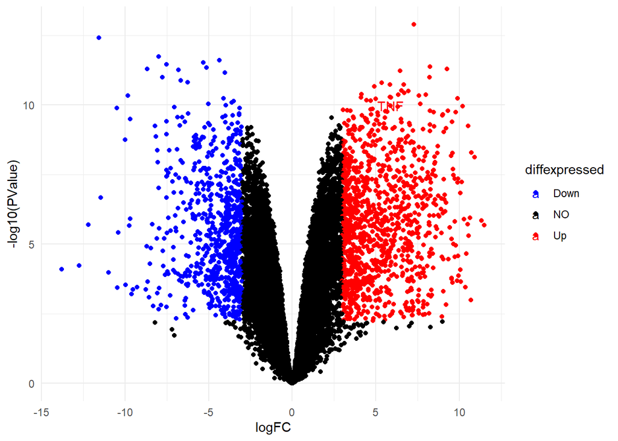

```r
allDEStats_unpaired$diffexpressed <- "NO"
allDEStats_unpaired$diffexpressed[allDEStats_unpaired$logFC > 3 & allDEStats_unpaired$FDR < 0.01]<-"Up"
allDEStats_unpaired$diffexpressed[allDEStats_unpaired$logFC < (-3) & allDEStats_unpaired$FDR < 0.01]<-"Down"
allDEStats_unpaired$delabel <- NA
allDEStats_unpaired$delabel[rownames(allDEStats_unpaired)=="TNF"]<-"TNF"
ggplot(data=allDEStats_unpaired, aes(x=logFC, y=-log10(PValue), col=diffexpressed, label=delabel))+geom_point()+theme_minimal()+geom_text()+scale_color_manual(values=c("blue", "black", "red"))
```

###Since I have corrected the labels, so this time the TNF should show in up-regulated genes, so logFC is correctly expressed as log(LCLs/B-cells).

#### Question 2d (2pts)

*In the case of this experiment, each donor had corresponding B cell and LCL samples - these are indicated by the ‘donor’ variable, which takes the values A-E. For instance, the LCLs and B-cells labeled with Donor ‘E’ are both from the same individual. What happens if there are person-specific differences in expression? For instance, what if person E had autoimmune disease? This could perturb both their B-cells and their resulting LCLs. These are called ‘paired samples’ since there is a pair of samples for each donor (B cells and LCLs). Repeat the analysis above, this time incorporating the knowledge of paired samples in the analysis, using the donor as a blocking variable.*

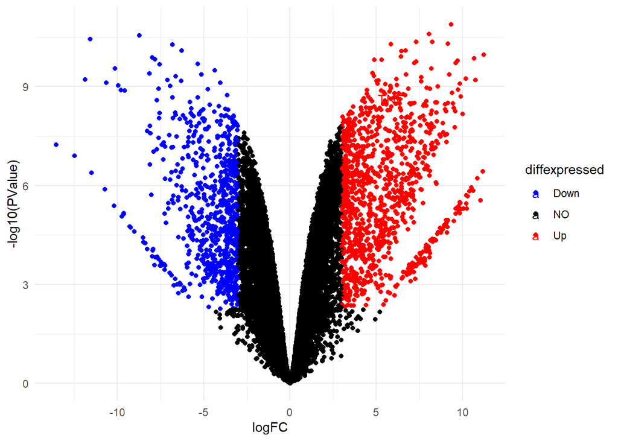

```r
donor<-as.factor(gsub("([A-Z]+)_([ABCDE])","\\2",colnames(countMatrix)))
design = model.matrix(~donor+ct)
res= estimateDisp(res,design)
fit= glmQLFit(res,design)
qlf = glmQLFTest(fit, coef=6)
allDEStats_paired = as.data.frame(topTags(qlf,n=nrow(countMatrix)))
allDEStats_paired$Gene.ID=row.names(allDEStats_paired)

allDEStats_paired$diffexpressed <- "NO"
allDEStats_paired$diffexpressed[allDEStats_paired$logFC > 3 & allDEStats_paired$FDR < 0.01]<-"Up"
allDEStats_paired$diffexpressed[allDEStats_paired$logFC < (-3) & allDEStats_paired$FDR < 0.01]<-"Down"
allDEStats_paired$delabel <- NA
allDEStats_paired$delabel[rownames(allDEStats_paired)=="TNF"]<-"TNF"
ggplot(data=allDEStats_paired, aes(x=logFC, y=-log10(PValue), col=diffexpressed, label=delabel))+geom_point()+theme_minimal()+geom_text()+scale_color_manual(values=c("blue", "black", "red"))
```

### Question 3

*When performing any bioinformatic analysis, it is critically important to verify your answers. Here, we’re going to compare the results from our paired analysis vs. the unpaired analysis to ensure that our analysis is correct (go back and redo the previous parts if you find that your analysis appears to be incorrect).*

#### Question 3a ( 1pts)

*Compare the results from the paired analysis vs. the original analysis (where donor was not considered).* *How many genes have a logFC that differs by 1 or more?*

```r
diff_indices <- c()
orderpaired <- allDEStats_paired[order(row.names(allDEStats_paired)), ]
orderunpaired <- allDEStats_unpaired[order(row.names(allDEStats_unpaired)), ]
lengthlog <- 0
for(i in 1:nrow(orderpaired)){

  if(abs(orderunpaired$logFC[i] - orderpaired$logFC[i]) >= 1){

    lengthlog = lengthlog +1
    diff_indices <- c(diff_indices,i)

  }
}


print(lengthlog)
```

```
## [1] 88
```

#### Question 3b ( 3pts)

*Plot the logFC values for paired (x-axis) vs unpaired (y-axis) analyses. What is the Pearson r between the two?*

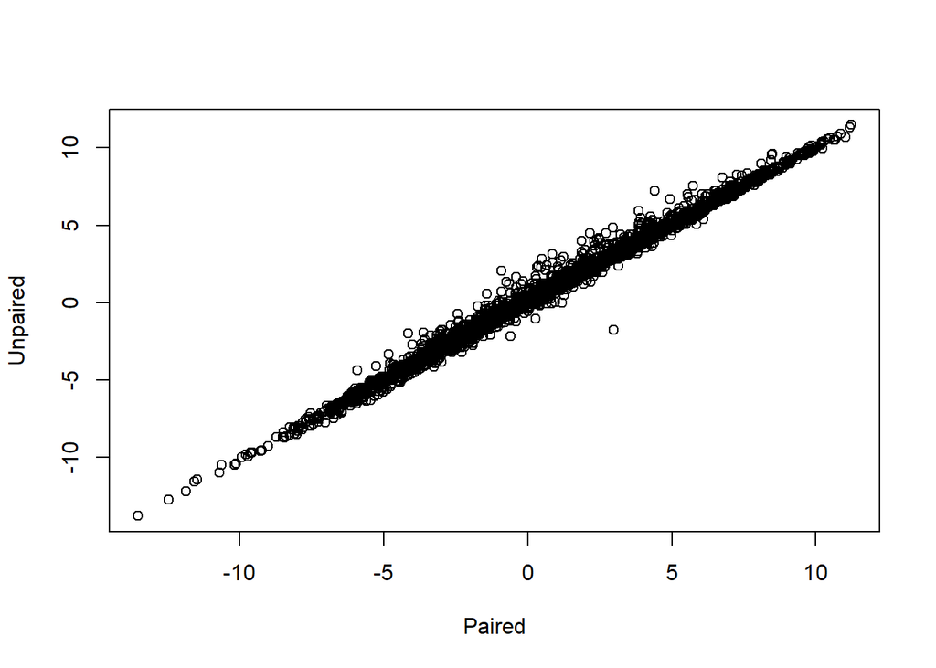

```r
Unpaired <- orderunpaired$logFC
Paired <- orderpaired$logFC
plotted <- plot(Paired, Unpaired)
```

```r
correlation2<-cor(Paired,Unpaired, method = "pearson")
correlation2
```

```
## [1] 0.9967738
```

#### Question 3c

*Why are there some genes whose logFC estimates differ so much between the paired and unpaired analyses? Let’s inspect the genes with a logFC difference between paired and unpaired of at least 1. A heatmap can be used to display a matrix of values. In this case, we want the values to represent log(RPKM+1) values (use `rnaSeqDataMeltedRPKM`), with genes (only those whose logFCs differ between the analysis using donor as a blocking variable vs. without by more than 1) on the y axis and samples on the x axis.*

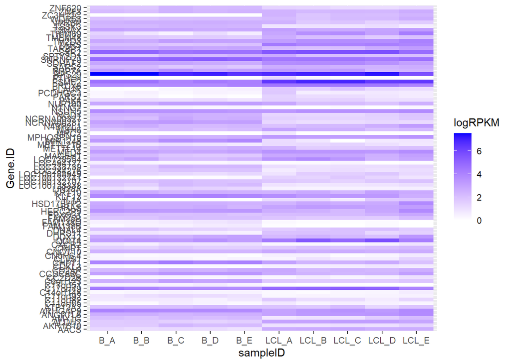

```r
#rnaSeqDataMeltedRPKM$RPKM

genegreater <- vector(mode = "character", length = 88)
rpkmgreater <- vector(mode = "character", length = 88)
#filteredlog <- vector(mode="numeric", length = length(rnaSeqDataMeltedRPKM$Gene.ID))
#rpkmordered <- rnaSeqDataMeltedRPKM[order(row.names(rnaSeqDataMeltedRPKM)), ]
#rpkmnew = cast(rpkmordered, Gene.ID ~ sampleID, value="RPKM", fun.aggregate="sum")
for(i in 1:88){
  ind<-diff_indices[i]
  genegreater[i] <- allDEStats_paired$Gene.ID[ind]

}

rpkmgreater <- rnaSeqDataMeltedRPKM[which(rnaSeqDataMeltedRPKM$Gene.ID %in% genegreater), ]
rpkmgreater$logRPKM <- log(rpkmgreater$RPKM + 1)

ggplot(rpkmgreater, aes(sampleID, Gene.ID, fill = logRPKM)) + geom_tile() + scale_fill_gradient(low="white", high="blue")
```

```r
#logmat <- matrix(0, nrow = 23228, ncol = 11)
#colnames(logmat) <- c("Gene.ID", "B_A", "B_B", "B_C", "B_D", "B_E", "LCL_A", "LCL_B", "LCL_C", "LCL_D", "LCL_E")
#rownames(logmat) <- rownames(rpkmnew)
#logmat[,1] <- rpkmnew$Gene.ID
#for(i in 1:length(rpkmordered))
#  for( n in 2:length(rpkmnew))
#    if (abs(orderunpaired$logFC[i] - orderpaired$logFC[i]) >= 1){
#      logmat[i,n] <- rpkmnew[i,n]
#    }else{
#      logmat[i,n] <- 0
#    }
#lengthlog2

#lengthlog
#rpkm<-log(rpkmMatrix+1)
#pheatmap(rpkm)
```

*What are some reasons why paired and unpaired analyses appear to be giving different answers in this case? Are there donor-specific things going on?*

No donor specific things going on. Since the paired analysis removed any possible repetitions in the analysis, we then presumably get lower values for a majority of the readings.

### Question 4

*There are many different ways of normalizing RNA seq data and they all make different assumptions.*

*For more information on RNA-seq normalization methods, see this great post by Harold Pimentel: https://haroldpimentel.wordpress.com/2014/05/08/what-the-fpkm-a-review-rna-seq-expression-units/*

#### *From now on, we will be using only the paired (donor as blocking variable) analysis*

#### Question 4a ( 3.5 pts)

*edgeR uses TMM normalization. TMM normalization is usually a solid approach, but it assumes that most of the genes do not differ in expression between your samples. One approach you could use to check this is by looking at the P-value distribution from our DE analysis. For a well-behaved statistical test, P-values are uniformly distributed between 0 and 1. Plot the Cumulative Distribution of P-values for the paired analysis. On the same plot, include a CDF for 100,000 uniformly sampled random values between 0 and 1.*

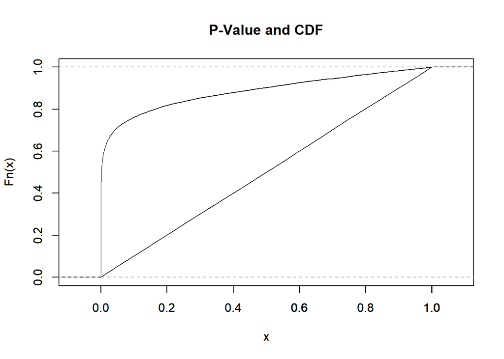

```r
rand.unif <- runif(100000, min = 0, max = 1)
plot(ecdf(orderpaired$PValue), main="P-Value and CDF")
par(new = TRUE)
plot(ecdf(rand.unif), main = " ")
```

*Do the P-values calculated by edgeR look like they are sampled uniformly between 0 and 1?*

*Estimate the fraction of genes that appear to have differential expression (does not have to be exact):*

*Do you think we should use TMM normalization for these samples? Why or why not?*

#### Question 4b (3.5 pts)

*Another way to ensure that P-values are well-behaved is to make a Q-Q plot. A Q-Q plot, in this case, will show the expected P-values (under the null hypothesis) on the x axis, and actual p-values on the y-axis. Recall that by the definition of a P-value, if you generate `n` p-values under the null hypothesis, you expect to see 1 p-value of 1/`n` or lower, two of 2/`n` or lower, etc. Here, `n` is the number of DE tests you performed. Make a Q-Q plot of p-values for your DE analysis. Use -log(P) for both axes (this puts the most significant in the upper right, and least significant in the lower left). Also include the line y=x in red for comparison. For a well-behaved statistical test, most of the points should lie along the y=x line.*

*Do most of the P-values lie along the y=x line?*

*What does this mean about how we did our analysis? What would you do differently if we were to redo the analysis?*

#### Question 4c (3 pts) *FDRs are automatically calculated by edgeR. plot the -log10(FDR) (y axis) versus the -log10(P-value) (x axis) for the paired DE analysis. Include the line y=x in red again for reference*

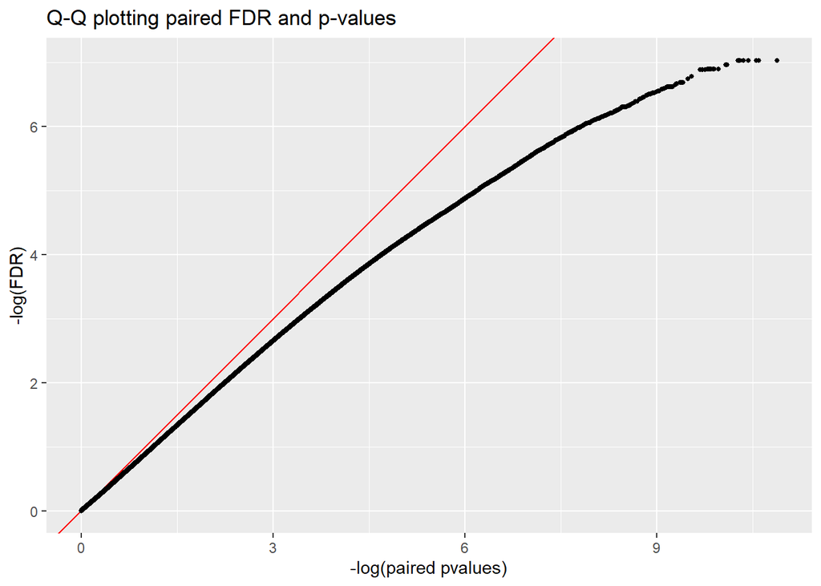

```r
ggplot(allDEStats_paired,aes(x = -log10(PValue), y = -log10(FDR))) + geom_abline(a = 0, b = 1, color = 'red') + geom_point(size = 1) + xlab("-log(paired pvalues)") + ylab("-log(FDR)") + ggtitle ("Q-Q plotting paired FDR and p-values")
```

*Are the points above or below the line? Why?* The points are below the line, but much closer to the actual pvalues because the FDR values corrects the multiple tests.

#### Question 4d (3 pts)

*If we took our set of significant DE genes to be those that meet an FDR of 10%, how many genes would be considered significantly DE?*

*What is the P-value of the gene with the highest FDR that is still less than or equal to FDR < 10%?*

*Ignoring any potential flaws in the analysis up to this point and assuming our P-values and FDRs are well founded, is the probability of this gene NOT being differentially expressed (ie. a false discovery) greater than, less than, or equal to 10%?*

### Question 5

*Now we’re going to spend some time actually looking at the results of our analysis, trying to determine what is going on when B-cells are converted to LCLs.*

#### Question 5a (2 pts)

*GOrilla, which we use below, can take a single ranked list as input. Here, you should make two ranked lists of gene IDs, one with the gene IDs sorted by log FC from high to low, and the other from low to high. Use the paired analysis for this question. You will only want gene IDs written to the file (e.g. no row or column names, no quotes) - GOrilla will give error messages if it is not properly formatted.*

```r
lowtohigh <- allDEStats_paired[order(allDEStats_paired$logFC), ]
hightolow <- allDEStats_paired[order(allDEStats_paired$logFC,decreasing=TRUE), ]
genelowtohigh <- lowtohigh$Gene.ID
genehightolow <- hightolow$Gene.ID
writeLines(genelowtohigh, con = "lowtohigh.txt")
writeLines(genehightolow, con = "hightolow.txt")
```

#### Question 5b (6 pts)

*Now use GOrilla to measure gene set enrichment analysis for both sets of genes.* http://cbl-gorilla.cs.technion.ac.il/

*Use Homo sapiens; a single ranked list of genes (those we just created - run it twice, once per file); and all ontologies.*

*When inspecting the results, consider both the significance of the enrichment, the degree of enrichment, and the number of genes involved. For instance, a high-fold enrichment for a very specific term can give more insight than a more significant but lower fold enrichment for a more generic term. Alternatively, enrichments involving fewer genes are more likely to occur by chance, and so may have a high fold enrichment, but nonetheless be spurious.*

*What processes are relatively high in B cells?* multicellular organismal process regulation of ion transport cell adhesion biological adhesion

*Which are relatively high in LCLs?* adult heart development anatomical structure development cellular development process chemotaxis cell differentiation cell recognition? signalling pathways

*What do you think could be happening as B-cells are reprogrammed to LCLs?* The TNF Gene should be highly induced in LCLs to form B-cells again. However for the creation of LCLs from B-cells TNF might be removed from the B-cells